# 4PLC 方程拟合校准曲线

hiox-tech

2026-08-06

# 1 分析目的

本文演示如何使用 `ivdtools` 包的 `fit_equation()` 拟合四参数 Logistic （four-parameter logistic，4PLC）校准曲线，并检查收敛状态、残差、权重影响以及 正向和逆向预测。

4PLC 是非线性模型。成功返回拟合对象并不等同于模型适用；正式分析还应结合校准点设计、 上下平台覆盖、参数稳定性、残差结构、重复测量精密度及预先规定的接受标准进行判断。

```r
library(ivdtools)
library(readr)
```

# 2 4PLC 模型与主要函数

`ivdtools` 中 4PLC 对应 `E07`，也可以使用名称 `"4PLC"` 调用：

$$y = A + \frac{B-A}{1 +
(x/C)^D}$$

其中，$A$ 和 $B$ 表示两个渐近平台，$C$ 表示曲线中点对应的浓度尺度，$D$ 控制曲线 方向和陡峭程度。参数含义应结合实际信号方向解释。

| 函数 | 用途 |
| --- | --- |
| `list_equation()` | 查看内置方程注册表 |
| `replicate_to_mean()` | 汇总重复测量并可计算权重 |
| `fit_equation()` | 拟合内置或自定义方程 |
| `coef()` | 提取模型参数 |
| `residuals()` | 提取观测值减拟合值的残差 |
| `predict()` | 正向预测响应值或逆向估计浓度 |
| `plot()` | 绘制观测点、拟合曲线和区间 |
| `compare_equation()` | 比较候选方程 |

查看响应曲线模型：

```r
list_equation(category = "Response")
```

```
#>   ID       Name                         Formula        Params nP Engine
#> -----------------------------------------------------------------------
#>  E01     Linear                         a + b*x          a, b  2     lm
#>  E02  Quadratic                 a + b*x + c*x^2       a, b, c  3     lm
#>  E03 ExpoGrowth                  a * exp(b * x)          a, b  2    nls
#>  E04  ExpoDecay                 a * exp(-b * x)          a, b  2    nls
#>  E05      Power                         a * x^b          a, b  2    nls
#>  E06        Log                  a + b * log(x)          a, b  2     lm
#>  E07       4PLC   A + (B - A) / (1 + (x / C)^D)    A, B, C, D  4    nls
#>  E08       5PLC A + (B - A) / (1 + (x / C)^D)^E A, B, C, D, E  5    nls
#>  E09   Gaussian a * exp(-(x - b)^2 / (2 * c^2))       a, b, c  3    nls
#>  E10  Michaelis             Vmax * x / (Km + x)      Vmax, Km  2    nls
#>  E11 Sinusoidal          a * sin(b * x + c) + d    a, b, c, d  4    nls
#>  E12      Cubic         a + b*x + c*x^2 + d*x^3    a, b, c, d  4     lm
```

`fit_equation()` 可以使用自动初值，也可以通过 `start` 指定初值；`lower`、`upper` 和 `constraints` 可设置参数边界或约束。`weights` 接受数值向量或内置方案 `"equal"`、`"1/y"`、`"1/y^2"`、`"1/x"`、`"1/x^2"`。

> **注意：** 权重应反映测量误差或方差结构，不能只根据曲线是正相关还是负相关来选择。 最好依据重复测量精密度、残差诊断或研究方案预先确定权重。

# 3 示例一：基本拟合流程

## 3.1 读取和核验数据

```r
u1 <- read_csv("./data/4PLC-U1.csv", show_col_types = FALSE)
u1
```

| Sample | Con | RLU |
| --- | --- | --- |
| s1 | 0.00 | 1581 |
| s2 | 4.08 | 3857 |
| s3 | 24.93 | 12931 |
| s4 | 92.75 | 36153 |
| s5 | 338.54 | 106083 |
| s6 | 1017.55 | 303726 |

```r
str(u1)
```

```
#> spc_tbl_ [6 × 3] (S3: spec_tbl_df/tbl_df/tbl/data.frame)
#>  $ Sample: chr [1:6] "s1" "s2" "s3" "s4" ...
#>  $ Con   : num [1:6] 0 4.08 24.93 92.75 338.54 ...
#>  $ RLU   : num [1:6] 1581 3857 12931 36153 106083 ...
#>  - attr(*, "spec")=
#>   .. cols(
#>   ..   Sample = col_character(),
#>   ..   Con = col_double(),
#>   ..   RLU = col_double()
#>   .. )
#>  - attr(*, "problems")=<externalptr>
```

```r
summary(u1[c("Con", "RLU")])
```

```
#>       Con                RLU
#>  Min.   :   0.000   Min.   :  1581
#>  1st Qu.:   9.293   1st Qu.:  6126
#>  Median :  58.840   Median : 24542
#>  Mean   : 246.308   Mean   : 77388
#>  3rd Qu.: 277.092   3rd Qu.: 88600
#>  Max.   :1017.550   Max.   :303726
```

```r
anyDuplicated(u1$Sample)
```

```
#> [1] 0
```

```r
sum(!is.finite(u1$Con) | !is.finite(u1$RLU))
```

```
#> [1] 0
```

该数据包含 6 个浓度水平。4PLC 需要估计 4 个参数，因此剩余自由度很少；同时最高浓度 仍未清楚覆盖上平台，模型参数可能不稳定。本例主要用于说明操作流程，不应直接作为正式 校准设计范例。

如果每个浓度包含重复测量，可以直接拟合全部观测，也可以先使用 `replicate_to_mean()` 汇总。是否汇总及如何加权应在分析方案中说明。

## 3.2 拟合并检查收敛

```r
fit_u1 <- fit_equation(
  "4PLC",
  data = u1,
  x = "Con",
  y = "RLU"
)
print(fit_u1)
```

```
#> E07 (4PLC)
#> Formula: A + (B - A) / (1 + (x / C)^D)
#>
#> Call:
#>   fit_equation(eq = "4PLC", data = u1, x = "Con", y = "RLU")
#>
#> Residuals:
#>       Min       1Q   Median       3Q      Max
#>     -1991.214  -1335.541  -252.849  960.620  2652.956
#>
#> Coefficients:
#>       Estimate  Std. Error  t value Pr(>|t|)
#> A  3.10445e+03 2.09875e+03  1.47919 0.277197
#> B  6.13447e+07 2.60964e+09  0.02351 0.983380
#> C  2.60778e+05 1.18118e+07  0.02208 0.984391
#> D -9.58182e-01 1.20691e-01 -7.93917 0.015498 *
#> ---
#> Signif. codes:  0 '***' 0.001 '**' 0.01 '*' 0.05 '.' 0.1 ' ' 1
#>
#> Residual standard error: 2775.94 on 2 degrees of freedom
#> AIC: 115.58  Iterations: 50
```

不要忽略优化器的收敛信息：

```r
fit_u1$fit$convInfo[c("isConv", "finIter", "stopCode", "stopMessage")]
```

```
#> $isConv
#> [1] FALSE
#>
#> $finIter
#> [1] 50
#>
#> $stopCode
#> [1] -1
#>
#> $stopMessage
#> [1] "Number of iterations has reached `maxiter' == 50."
```

本数据的默认拟合达到迭代次数上限且未声明收敛。增加最大迭代次数有时有帮助，但不能解决 校准范围未覆盖平台或参数不可辨识的问题。遇到未收敛时，应依次检查数据、模型方向、初值、 参数边界和校准点设计，而不是仅凭曲线外观接受结果。

## 3.3 残差与图形

```r
u1_diagnostics <- data.frame(
  Sample = u1$Sample,
  Con = u1$Con,
  RLU = u1$RLU,
  Residual = residuals(fit_u1),
  Relative_residual_pct = residuals(fit_u1) / u1$RLU * 100
)
knitr::kable(u1_diagnostics, digits = 2)
```

| Sample | Con | RLU | Residual | Relative_residual_pct |
| --- | --- | --- | --- | --- |
| s1 | 0.00 | 1581 | -1523.45 | -96.36 |
| s2 | 4.08 | 3857 | -771.83 | -20.01 |
| s3 | 24.93 | 12931 | 1192.12 | 9.22 |
| s4 | 92.75 | 36153 | 2652.96 | 7.34 |
| s5 | 338.54 | 106083 | -1991.21 | -1.88 |
| s6 | 1017.55 | 303726 | 266.13 | 0.09 |

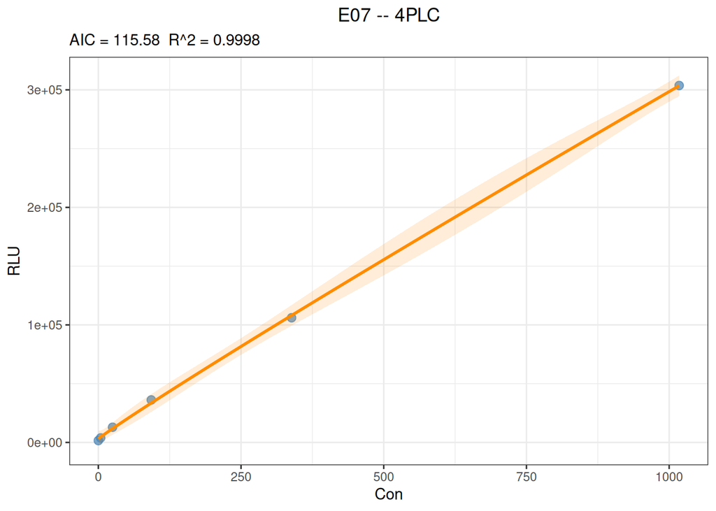

```r
plot(fit_u1, interval = "confidence", level = 0.95)
```

残差应同时在原始响应尺度和相对尺度上检查，并结合重复测量方差判断。对跨越多个数量级的 响应，仅查看原始残差可能使高信号点主导判断。

## 3.4 由浓度预测响应

```r
predict(
  fit_u1,
  newdata = data.frame(Con = c(20, 200, 1000)),
  interval = "confidence",
  level = 0.95
)
```

```
#>     x         y   y_ci_lwr  y_ci_upr
#>    20  10095.70   5194.229  14997.17
#>   200  66540.68  59494.141  73587.22
#>  1000 298518.29 289967.527 307069.05
```

均值置信区间描述拟合均值的不确定性；预测区间还包含单次观测误差，通常更宽：

```r
predict(
  fit_u1,
  newdata = data.frame(Con = c(20, 200, 1000)),
  interval = "prediction",
  level = 0.95
)
```

```
#>     x         y      y_pi_lwr  y_pi_upr
#>    20  10095.70     -7.215948  20198.61
#>   200  66540.68  55240.318293  77841.05
#>  1000 298518.29 286223.575001 310813.01
```

## 3.5 由响应逆向估计浓度

```r
predict(
  fit_u1,
  newdata = data.frame(RLU = c(20000, 100000, 250000)),
  inverse = TRUE
)
```

```
#>         x      y
#>   50.2395  20000
#>  311.3672 100000
#>  828.5559 250000
```

> **预测边界：** 应避免超出校准浓度范围外推。逆向预测在平台区对响应误差非常敏感， 非单调模型还可能出现多解。当前示例拟合未可靠收敛，因此预测仅用于演示接口，不能用于 定量结论。

# 4 示例二：夹心法与权重

## 4.1 等权重拟合

夹心法数据通常表现为浓度增加、信号升高。本例先进行等权重拟合：

```r
u2 <- read_csv("./data/4PLC-U2.csv", show_col_types = FALSE)

fit_u2_equal <- fit_equation(
  "4PLC",
  data = u2,
  x = "Con",
  y = "RLU"
)
print(fit_u2_equal)
```

```
#> E07 (4PLC)
#> Formula: A + (B - A) / (1 + (x / C)^D)
#>
#> Call:
#>   fit_equation(eq = "4PLC", data = u2, x = "Con", y = "RLU")
#>
#> Residuals:
#>       Min       1Q   Median       3Q      Max
#>     -1034493.852  -58331.509  17644.023  45830.410  785037.098
#>
#> Coefficients:
#>       Estimate  Std. Error  t value   Pr(>|t|)
#> A -4.19069e+04 2.74298e+05 -0.15278 0.88288329
#> B  4.01980e+08 9.51404e+08  0.42251 0.68532695
#> C  1.12895e+03 3.16059e+03  0.35720 0.73147078
#> D -1.02539e+00 1.32241e-01 -7.75390 0.00011121 ***
#> ---
#> Signif. codes:  0 '***' 0.001 '**' 0.01 '*' 0.05 '.' 0.1 ' ' 1
#>
#> Residual standard error: 565331 on 7 degrees of freedom
#> AIC: 327.64  Iterations: 24
```

## 4.2 反响应平方权重拟合

当响应方差随信号增大而明显增大时，可以评估反响应平方权重：

```r
fit_u2_weighted <- fit_equation(
  "4PLC",
  data = u2,
  x = "Con",
  y = "RLU",
  weights = "1/y^2"
)
print(fit_u2_weighted)
```

```
#> E07 (4PLC)
#> Formula: A + (B - A) / (1 + (x / C)^D)
#>
#> Call:
#>   fit_equation(eq = "4PLC", data = u2, x = "Con", y = "RLU", weights = "1/y^2")
#>
#> Residuals:
#>       Min       1Q   Median       3Q      Max
#>     -1038926.254  -2031.562  491.283  35707.649  809345.965
#>
#> Coefficients:
#>       Estimate  Std. Error    t value   Pr(>|t|)
#> A  5.66828e+03 2.30614e+02   24.57907 4.7016e-08 ***
#> B  2.00185e+08 6.72603e+07    2.97627   0.020624 *
#> C  4.83741e+02 1.74222e+02    2.77658   0.027433 *
#> D -1.08082e+00 1.02400e-02 -105.54858 1.8062e-12 ***
#> ---
#> Signif. codes:  0 '***' 0.001 '**' 0.01 '*' 0.05 '.' 0.1 ' ' 1
#>
#> Residual standard error: 0.042025 on 7 degrees of freedom
#> AIC: 265.29  Iterations: 7
```

比较两个模型在各校准点的相对残差：

```r
u2_comparison <- data.frame(
  Sample = u2$Sample,
  Con = u2$Con,
  RLU = u2$RLU,
  Equal_weight_pct = residuals(fit_u2_equal) / u2$RLU * 100,
  Inverse_y2_weight_pct = residuals(fit_u2_weighted) / u2$RLU * 100
)
knitr::kable(u2_comparison, digits = 2)
```

| Sample | Con | RLU | Equal_weight_pct | Inverse_y2_weight_pct |
| --- | --- | --- | --- | --- |
| c1 | 0.00 | 5637 | 843.43 | -0.55 |
| c2 | 0.05 | 16014 | 275.49 | 3.07 |
| c3 | 0.20 | 47520 | 67.84 | -4.70 |
| c4 | 0.51 | 125038 | 14.11 | -1.46 |
| c5 | 1.03 | 277621 | 4.57 | 4.70 |
| c6 | 5.19 | 1498023 | -4.39 | 0.98 |
| c7 | 10.92 | 3334387 | -1.53 | 1.70 |
| c8 | 20.83 | 6148959 | -6.53 | -5.30 |
| c9 | 49.90 | 16515788 | 4.75 | 4.13 |
| c10 | 95.47 | 28504677 | -3.63 | -3.64 |
| c11 | 112.18 | 35017203 | 1.75 | 2.31 |

```r
data.frame(
  Model = c("等权重", "1/y^2 权重"),
  Median_absolute_relative_residual_pct = c(
    median(abs(u2_comparison$Equal_weight_pct)),
    median(abs(u2_comparison$Inverse_y2_weight_pct))
  ),
  Maximum_absolute_relative_residual_pct = c(
    max(abs(u2_comparison$Equal_weight_pct)),
    max(abs(u2_comparison$Inverse_y2_weight_pct))
  )
) |>
  knitr::kable(digits = 2)
```

| Model | Median_absolute_relative_residual_pct | Maximum_absolute_relative_residual_pct |
| --- | --- | --- |
| 等权重 | 4.75 | 843.43 |
| 1/y^2 权重 | 3.07 | 5.30 |

在本示例数据中，`1/y^2` 权重明显降低了低信号点的相对残差；这只能说明该权重更符合 本数据所采用的相对误差评价目标。正式选择仍需结合各浓度重复测量的方差、回算浓度偏差、 模型参数稳定性和预设接受标准。不同权重下的残差标准误和 AIC 具有不同尺度，不宜脱离 误差模型直接比较。

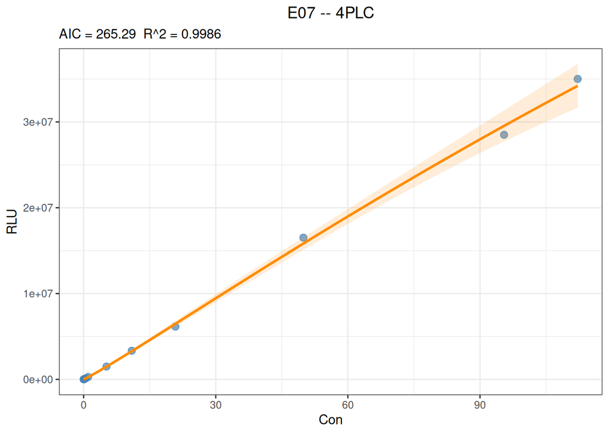

```r
plot(fit_u2_weighted, interval = "confidence", level = 0.95)
```

# 5 示例三：竞争法

竞争法数据通常表现为浓度增加、信号降低：

```r
u3 <- read_csv("./data/4PLC-U3.csv", show_col_types = FALSE)

fit_u3 <- fit_equation(
  "4PLC",
  data = u3,
  x = "Con",
  y = "RLU"
)
print(fit_u3)
```

```
#> E07 (4PLC)
#> Formula: A + (B - A) / (1 + (x / C)^D)
#>
#> Call:
#>   fit_equation(eq = "4PLC", data = u3, x = "Con", y = "RLU")
#>
#> Residuals:
#>       Min       1Q   Median       3Q      Max
#>     -1937.581  -454.210  -28.126  625.582  1807.765
#>
#> Coefficients:
#>       Estimate  Std. Error   t value   Pr(>|t|)
#> A -2.81576e+04 2.17005e+03  -12.9755 1.1793e-06 ***
#> B  1.40035e+06 1.08896e+03 1285.9562 < 2.22e-16 ***
#> C  1.29783e+02 6.49733e-01  199.7479 4.4162e-16 ***
#> D  7.82733e-01 2.79342e-03  280.2058 < 2.22e-16 ***
#> ---
#> Signif. codes:  0 '***' 0.001 '**' 0.01 '*' 0.05 '.' 0.1 ' ' 1
#>
#> Residual standard error: 1093.1 on 8 degrees of freedom
#> AIC: 207.11  Iterations: 5
```

```r
fit_u3$fit$convInfo[c("isConv", "finIter", "stopCode", "stopMessage")]
```

```
#> $isConv
#> [1] TRUE
#>
#> $finIter
#> [1] 5
#>
#> $stopCode
#> [1] 1
#>
#> $stopMessage
#> [1] "Relative error in the sum of squares is at most `ftol'."
```

```r
u3_diagnostics <- data.frame(
  Sample = u3$Sample,
  Con = u3$Con,
  RLU = u3$RLU,
  Relative_residual_pct = residuals(fit_u3) / u3$RLU * 100
)
knitr::kable(u3_diagnostics, digits = 2)
```

| Sample | Con | RLU | Relative_residual_pct |
| --- | --- | --- | --- |
| m1 | 0 | 1400548 | 0.01 |
| m2 | 40 | 991716 | -0.20 |
| m3 | 60 | 897247 | 0.20 |
| m4 | 79 | 822749 | -0.05 |
| m5 | 138 | 669646 | 0.11 |
| m6 | 187 | 585293 | 0.10 |
| m7 | 297 | 462119 | -0.07 |
| m8 | 523 | 330399 | -0.19 |
| m9 | 737 | 263095 | -0.25 |
| m10 | 1266 | 177260 | -0.12 |
| m11 | 1608 | 146827 | 0.11 |
| m12 | 2218 | 112252 | 0.61 |

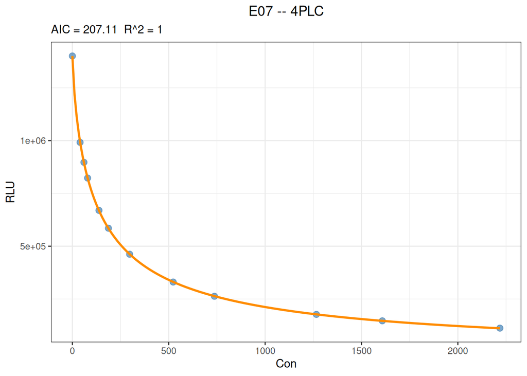

```r
plot(fit_u3, interval = "confidence", level = 0.95)
```

本例等权重拟合已经收敛且样本内相对残差较小，但仍应依据重复测量方差决定是否需要权重。 信号方向本身不是选择等权重或加权拟合的依据。

# 6 结果判读要点

1. **校准设计**：浓度点应覆盖预期工作区间，并尽可能提供上下平台信息。
2. **收敛状态**：检查 `convInfo`，不能把达到最大迭代次数直接视为成功收敛。
3. **参数合理性**：结合平台、曲线中点、方向、标准误和参数相关性判断稳定性。
4. **残差结构**：同时检查原始残差、相对残差及其随浓度或拟合值的变化。
5. **权重依据**：优先使用重复测量估计的方差结构，并在分析前规定选择规则。
6. **回算表现**：按项目要求评价各校准点的回算浓度偏差和精密度。
7. **预测范围**：避免外推，尤其避免在平台区进行不稳定的逆向预测。
8. **可复现性**：保存原始数据、代码、模型参数、包版本、图形和完整会话信息。